# Part II - ProsperLoan - Analysis of BorrowerAPR and Loan Characteristics

## by Emmanuel Michael - Feb 2023

## Investigation Overview

This presentation's main objective is to shed light on the variables that influence the annual percentage rate (BorrowerAPR) for Prosper loans. Exploratory data analysis (EDA) methods will be used in the presentation to examine a dataset of Prosper loans from 2005 to 2014. The key findings will be described and presented, along with visualizations that clearly convey the conclusions.

The distribution of borrower APR, the relationship between borrower APR and loan original amount, the relationship between borrower APR and ProsperRating, and the effect of delinquencies in the past 7 years on borrower APR across various income ranges and Prosper ratings are just a few of the key insights that will be presented.

In general, this presentation will give investors and borrowers useful information about the variables that determine BorrowerAPR and how to make wise choices while applying for or investing in Prosper loans.

## Dataset Overview

The dataset used in this presentation includes details on loans listings made available through a platform for lending named Prosper. It contains details of 113,937 loans with 81 different characteristics, including the loan amount, the borrower's APR, the loan's status, the borrower's work situation, and the borrower's income range, among others. The information includes loans that were made between November 2005 and March 2014.

## Distribution of BorrowerAPR

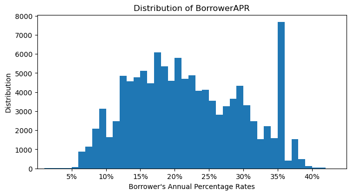

## BorrowerAPR vs ProsperRating

The Prosper Rating is a proprietary rating system used by Prosper to assess the creditworthiness of borrowers. It ranges from HR to AA, with HR being the lowest rating indicating the highest credit risk, and AA being the highest rating indicating the lowest credit risk. When examining the relationship between Borrower APR and Prosper Rating, we found that the two variables have a strong negative correlation. Borrowers with higher Prosper Ratings tend to receive lower APRs, indicating a lower credit risk, while borrowers with lower Prosper Ratings tend to receive higher APRs, indicating a higher credit risk. This relationship is consistent with what we would expect to see in the lending industry, where riskier borrowers are charged higher interest rates to compensate for the higher risk they pose to lenders.

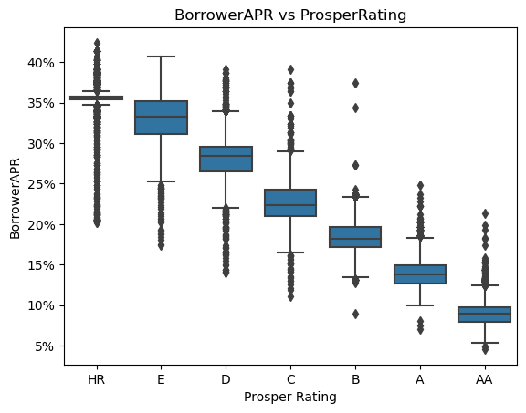

## BorrowerAPR vs LoanOriginalAmount

The relationship between Borrower APR and Loan Original Amount is negative, which means that as the loan amount increases, the Borrower APR tends to decrease. This makes sense as lenders may be willing to offer lower interest rates for larger loans since they stand to earn more interest overall. The scatter plot also shows that there are more data points for smaller loans, which may suggest that Prosper is used more for smaller loans.

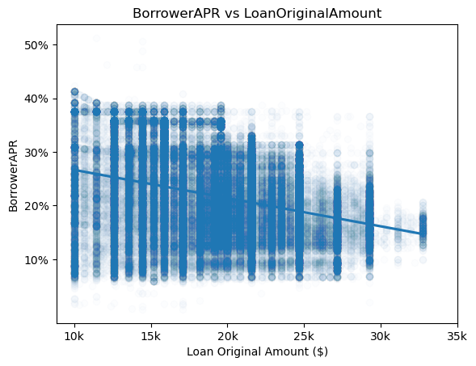

## Effect of delinquencies in the past 7 years on Borrower APR across various Income ranges and Prosper ratings

Because borrowers with more delinquencies or lower income ranges may be more financially vulnerable and have a harder time repaying their loans, which could result in defaults, this relationship is crucial to take into account. To make up for the extra risk, lenders may demand higher interest rates. It's also important to make sure that these borrowers aren't unfairly subjected to exorbitant interest rates. When deciding on loan approval and interest rates, lenders may take this relationship into account.

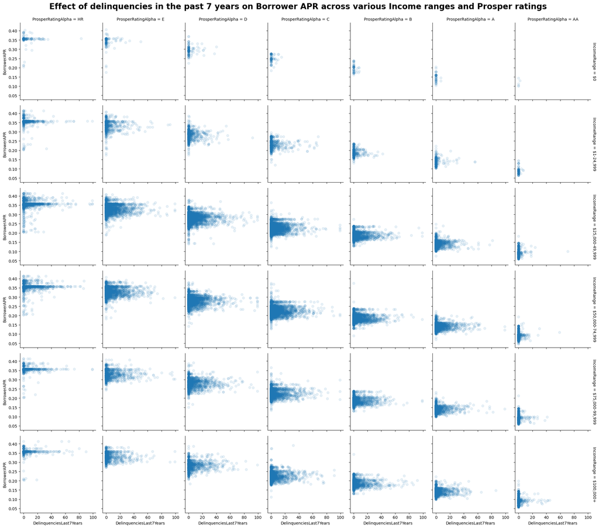